# Glowworms

[figure not shown]

We are investigating occurrence data of [**Glowworms**](https://en.wikipedia.org/wiki/Glowworm) in Australia from the **Atlas of Living Australia**, and make a map showing the spatial locations of sightings from 2014 to 2024.

This is the head of data set:

```
#> Rows: 3
#> Columns: 10
#> $ obs_lat        <dbl> -43.46804, -43.46398, -43.46257
#> $ obs_lon        <dbl> 146.9139, 146.8676, 146.8485
#> $ year           <dbl> 2016, 2021, 2015
#> $ month          <dbl> 11, 12, 12
#> $ day            <dbl> 29, 14, 9
#> $ weekday        <ord> Tuesday, Tuesday, Wednesday
#> $ dayofyear      <dbl> 334, 348, 343
#> $ datetime       <dttm> 2016-11-29 15:58:25, 2021-12-14 22:14:23, 2015-12-09 15…
#> $ scientificName <chr> "Arachnocampa", "Arachnocampa tasmaniensis", "Arachnoca…
#> $ obs_state      <chr> "Tasmania", "Tasmania", "Tasmania"
```

Now we want to know the number of occurrence in each state:

```
#> # A tibble: 10 × 7
#>    scientificName     `New South Wales` Queensland Tasmania Victoria  `NA` Total
#>    <chr>                          <int>      <int>    <int>    <int> <int> <dbl>
#>  1 Arachnocampa                      45         15        2       11     2    75
#>  2 Arachnocampa buff…                 0          0        0        1     0     1
#>  3 Arachnocampa flava                 4         47        0        0     0    51
#>  4 Arachnocampa gipp…                 0          0        0        1     0     1
#>  5 Arachnocampa girr…                 4          0        0        0     0     4
#>  6 Arachnocampa otwa…                 0          0        0       72     0    72
#>  7 Arachnocampa rich…                44          0        0        0     0    44
#>  8 Arachnocampa tasm…                 0          0       40        0     0    40
#>  9 Arachnocampa trop…                 0          5        0        0     0     5
#> 10 Total                             97         67       42       85     2   293
```

This is the selected species and in the next we will consider all `Arachnocampa` around `Arachnocampa flava` as a `falava` because `Arachnocampa` is a genus species.

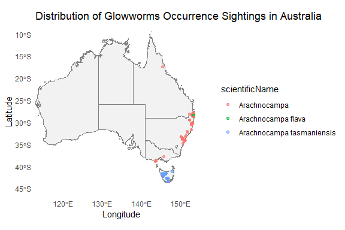

we want to assign genus “Arachnocampa” records to the “Arachnocampa flava” specie — based on how close they are geographically to other records.

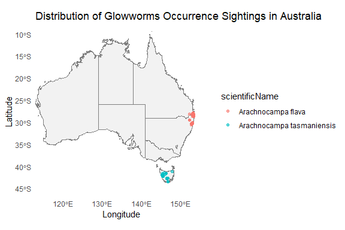

```
#> # A tibble: 3 × 5
#>   scientificName            `New South Wales` Queensland Tasmania Total
#>   <chr>                                 <int>      <int>    <int> <dbl>
#> 1 Arachnocampa flava                       23         61        0    84
#> 2 Arachnocampa tasmaniensis                 0          0       40    40
#> 3 Total                                    23         61       40   124
```

#### Weekly Distribution of organism

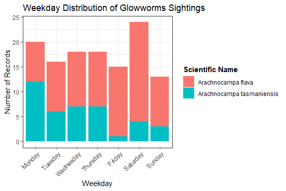

#### Monthly Distribution of organism

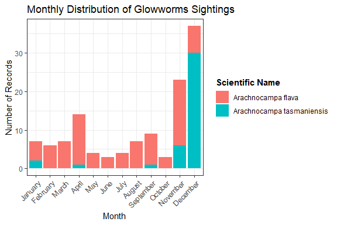

#### Yearly Distribution of organism

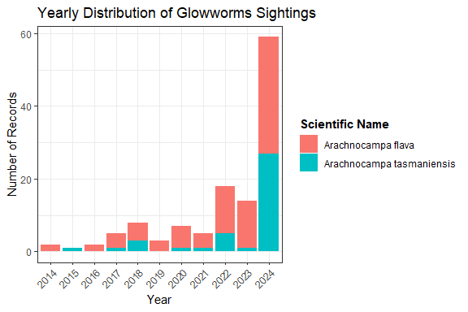

#### Nearest Weather Station Mapping

```
#> Nearest weather stations attached and saved as: glowworms_ws.rda
```

```
#> Rows: 2
#> Columns: 17
#> $ obs_lat            <dbl> -43.46398, -43.46257
#> $ obs_lon            <dbl> 146.8676, 146.8485
#> $ year               <dbl> 2021, 2015
#> $ month              <dbl> 12, 12
#> $ day                <dbl> 14, 9
#> $ weekday            <ord> Tuesday, Wednesday
#> $ dayofyear          <dbl> 348, 343
#> $ datetime           <dttm> 2021-12-14 22:14:23, 2015-12-09 15:00:24
#> $ scientificName     <chr> "Arachnocampa tasmaniensis", "Arachnocampa tasmanie…
#> $ obs_state          <chr> "Tasmania", "Tasmania"
#> $ weather_station_id <chr> "949610-99999", "949610-99999"
#> $ stname             <chr> "DOVER", "DOVER"
#> $ stn_lat            <dbl> -43.317, -43.317
#> $ stn_lon            <dbl> 147.017, 147.017
#> $ address            <chr> "Bay View Road, Dover, Huon Valley, Tasmania, 7117,…
#> $ stn_city           <chr> "Bay View Road", "Bay View Road"
#> $ stn_state          <chr> "Tasmania", "Tasmania"
```

```
#>             State Observed WeatherStation
#> 2      Queensland       61             17
#> 3        Tasmania       40             40
#> 1 New South Wales       23             67
```

Interpretation:

- Queensland:  
  61 of your organism records were observed in Queensland.  
  However, only 17 of those were linked to weather stations also located in Queensland.
- Tasmania:  
  40 observations were made in Tasmania, and  
  All 40 were matched to Tasmanian weather stations — a perfect match.
- New South Wales:  
  23 observations occurred there,  
  But 67 records were linked to weather stations in New South Wales — suggesting many observations from other states were matched to NSW stations.

#### Pattern Analysis

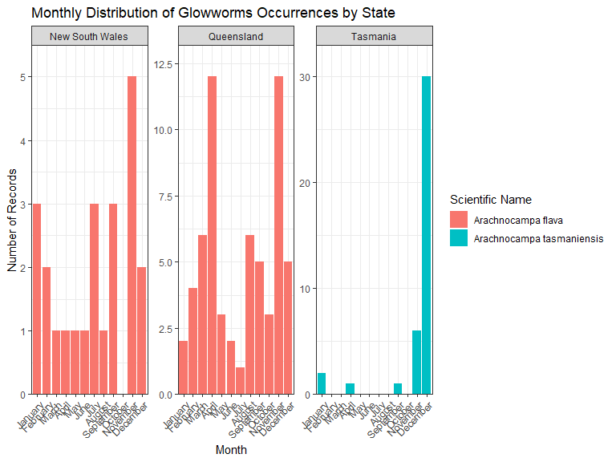

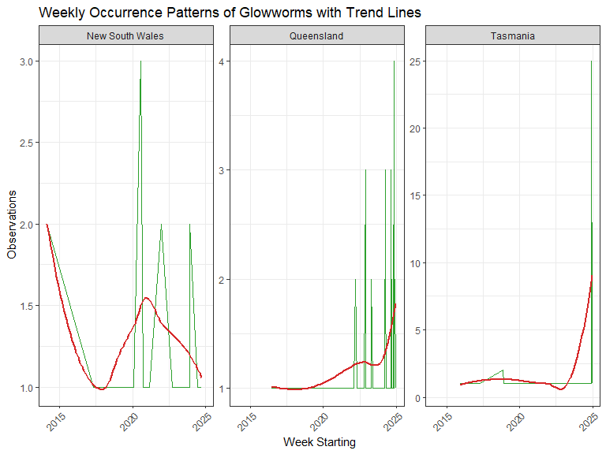

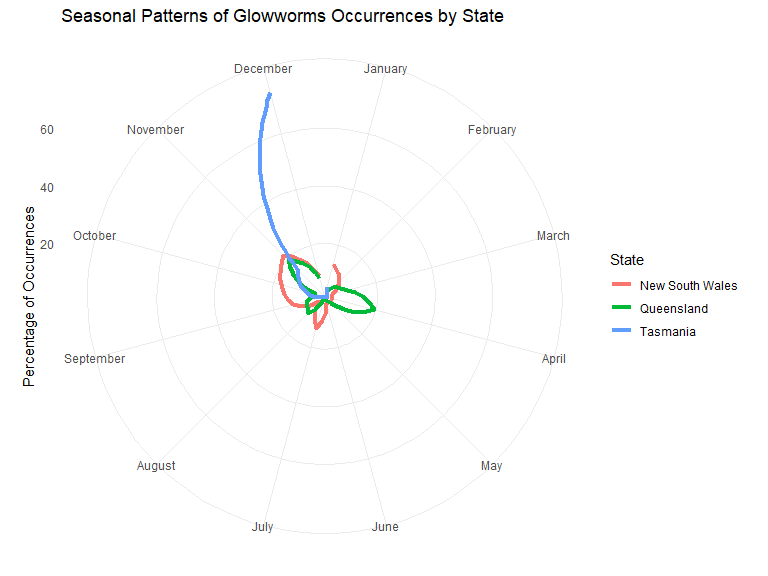

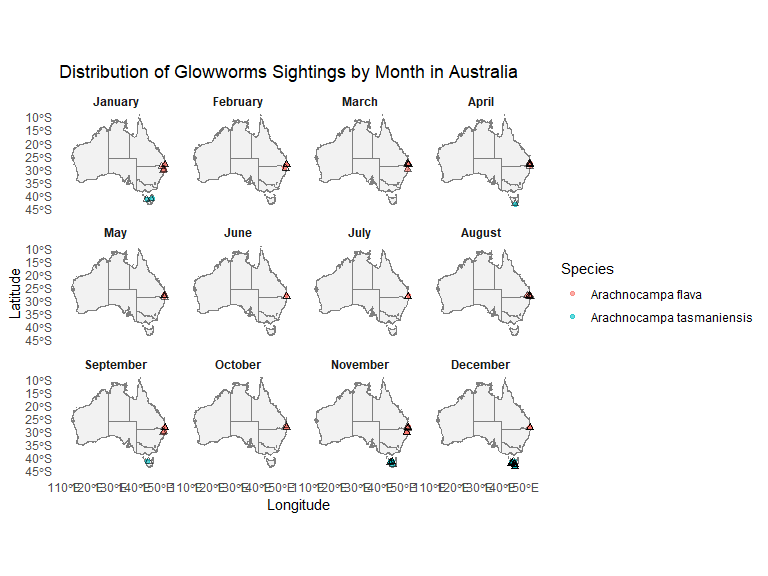

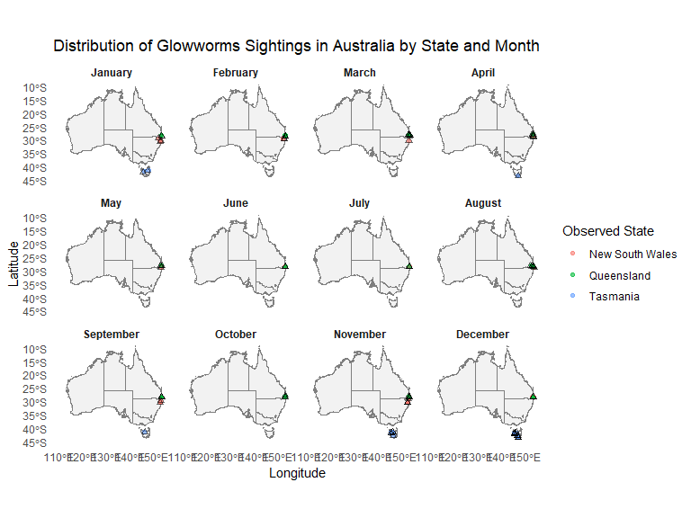

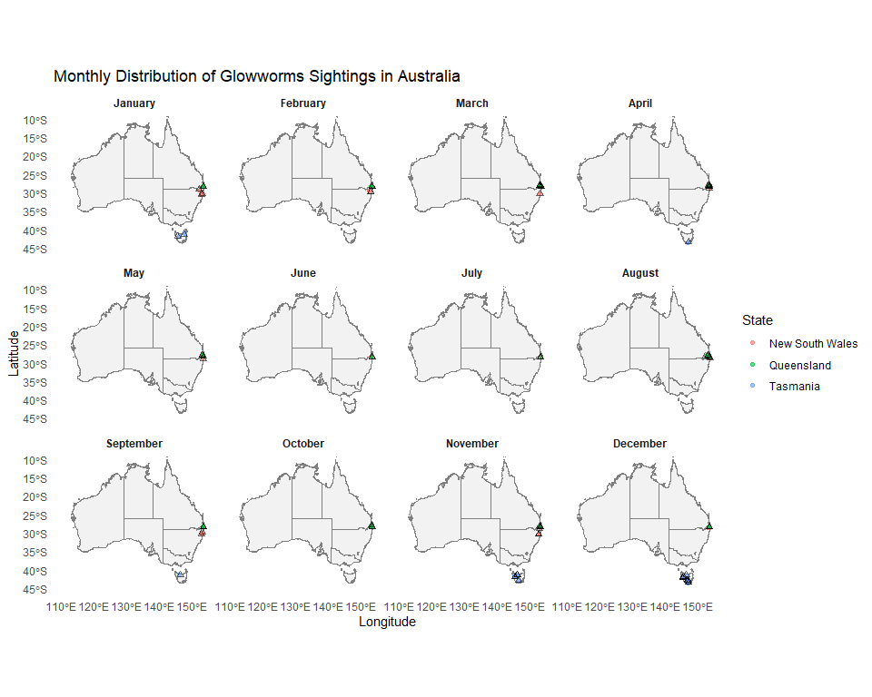

## 📦 Datasets Overview

The occurrence and weather station data have been processed and organized into the following structured datasets, all stored in the `data/` directory:

### `glowworms.rda`

Contains raw occurrence records for the target organism across various regions, including key spatial and temporal fields such as latitude, longitude, observation date/time, and administrative boundaries (e.g., state or territory).

### `glowworms_ws.rda`

An enhanced version of the occurrence dataset in which each record has been spatially matched to its **nearest weather station**. This dataset includes additional metadata fields:

```
- weather_station_id  : ID of the nearest weather station
- stname              : Weather station name
- stn_lat, stn_lon    : Coordinates of the weather station
- stn_state, stn_city : Location details of the station
```

### `glowworms_top_weather.rda`

A subset of weather data extracted from the **top N most frequently linked weather stations** in `glowworms_ws.rda`, used to investigate environmental patterns surrounding the most common observation sites.

### `weather_stations.rda`

A complete reference dataset of unique weather stations, including their identifiers, names, coordinates, and associated administrative metadata. This serves as a lookup or cross-reference for station matching and environmental analysis.